# Votos na Flórida, eleição do ano 2000.

Esta tabela foi retirada do pacote carData, contendo vários bancos de dados.

O banco de dados foi escolhido, ao acaso. Ele corresponde às eleições presidenciais americanas de 2000, mais especificamente no estado da Flórida.

Percebi que se tratava da contagem de votos, quando prestei atenção no nome das colunas.

Logo me veio à memória a primeira vez que ouvi sobre aquecimento global, no documentário do [Gore](https://www.youtube.com/watch?v=Qm6_H2G73p8). E como o presidente Bush dos EUA, no meu período de infância, parecia ser muito odiado.

Dito isso, vamos fazer uma análise rápida destes dados.

```r
knitr::opts_chunk$set(
  fig.width = 10, fig.height = 6,   tidy=TRUE,message = F, warning = F, tidy.opts=list(arrow=TRUE,  indent=2))
```

# Pacotes utilizados

```r
library(tidyverse)
library(knitr)
library(rmarkdown)
```

# Transformação dos dados

A tabela da Flórida da biblioteca `carData` será usada como fonte.

```r
florida <- carData::Florida
kable(head(florida, 5))
```

|  | GORE | BUSH | BUCHANAN | NADER | BROWNE | HAGELIN | HARRIS | MCREYNOLDS | MOOREHEAD | PHILLIPS | Total |
| --- | --- | --- | --- | --- | --- | --- | --- | --- | --- | --- | --- |
| ALACHUA | 47300 | 34062 | 262 | 3215 | 658 | 42 | 4 | 658 | 21 | 20 | 86242 |
| BAKER | 2392 | 5610 | 73 | 53 | 17 | 3 | 0 | 0 | 3 | 3 | 8154 |
| BAY | 18850 | 38637 | 248 | 828 | 171 | 18 | 5 | 3 | 37 | 18 | 58815 |
| BRADFORD | 3072 | 5413 | 65 | 84 | 28 | 2 | 0 | 0 | 3 | 2 | 8669 |
| BREVARD | 97318 | 115185 | 570 | 4470 | 643 | 39 | 11 | 11 | 76 | 72 | 218395 |

Irei transformar as linhas em uma coluna chamada município, para se tornar o mais próximo do formato `tidy`.

```r
# Acrescentei uma coluna municipio
florida$Municipios <- rownames(florida)

# A coloquei em primeiro
florida <- florida %>%
  select(Municipios, everything())

# Converter o dataframe em um tidy
florida <- as_tibble(florida)

# Mostrar como uma tabela bonitinha
kable(head(florida, 5), caption = "Votos por Município na Florida")
```

Votos por Município na Florida

| Municipios | GORE | BUSH | BUCHANAN | NADER | BROWNE | HAGELIN | HARRIS | MCREYNOLDS | MOOREHEAD | PHILLIPS | Total |
| --- | --- | --- | --- | --- | --- | --- | --- | --- | --- | --- | --- |
| ALACHUA | 47300 | 34062 | 262 | 3215 | 658 | 42 | 4 | 658 | 21 | 20 | 86242 |
| BAKER | 2392 | 5610 | 73 | 53 | 17 | 3 | 0 | 0 | 3 | 3 | 8154 |
| BAY | 18850 | 38637 | 248 | 828 | 171 | 18 | 5 | 3 | 37 | 18 | 58815 |
| BRADFORD | 3072 | 5413 | 65 | 84 | 28 | 2 | 0 | 0 | 3 | 2 | 8669 |
| BREVARD | 97318 | 115185 | 570 | 4470 | 643 | 39 | 11 | 11 | 76 | 72 | 218395 |

# Gráficos

Depois de muita luta, organizar os 10 municípios que mais votam em:

# Número de Votos

## Gore

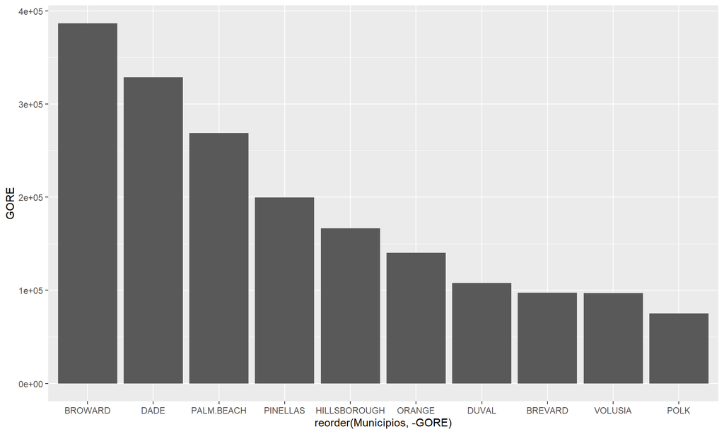

```r
florida %>%
  top_n(10, GORE) %>%
  ggplot(aes(y = GORE, x = reorder(Municipios, -GORE))) + geom_bar(stat = "identity")
```

## Bush

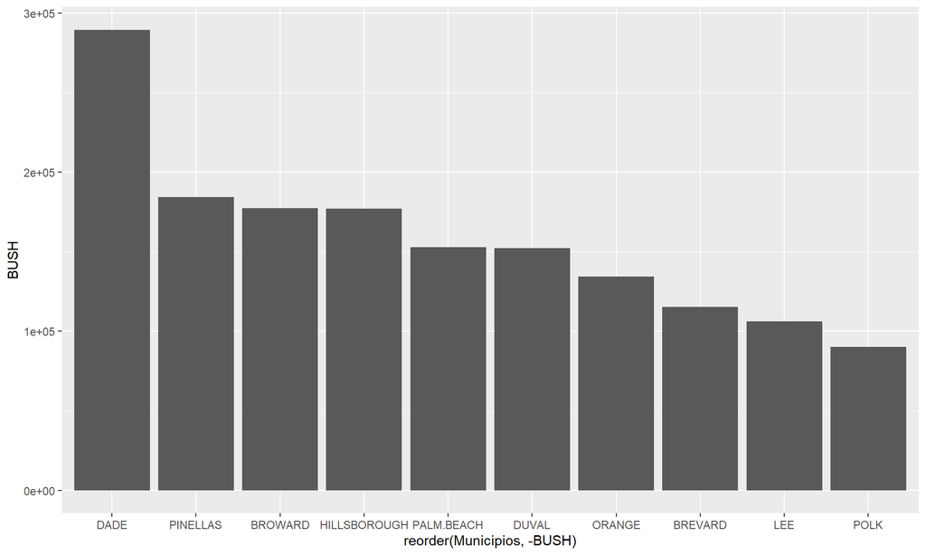

```r
florida %>%
  top_n(10, BUSH) %>%
  ggplot(aes(y = BUSH, x = reorder(Municipios, -BUSH))) + geom_bar(stat = "identity")
```

## Total

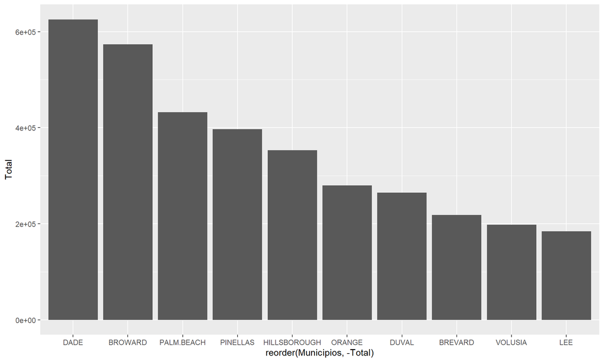

```r
florida %>%
  top_n(10, Total) %>%
  ggplot(aes(y = Total, x = reorder(Municipios, -Total))) + geom_bar(stat = "identity")
```

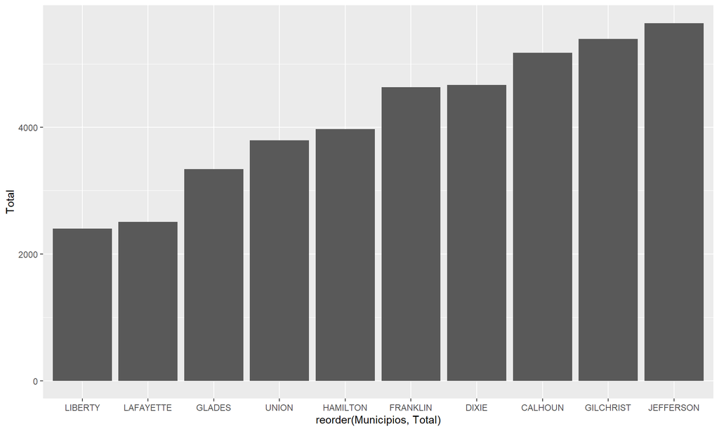

```r
florida %>%
  top_n(-10, Total) %>%
  ggplot(aes(y = Total, x = reorder(Municipios, Total))) + geom_bar(stat = "identity")
```

# Porcentagem de votos por município

Ele será feito com as porcentagem por município

```r
# A linha estudada será definidada por n
n <- 50
```

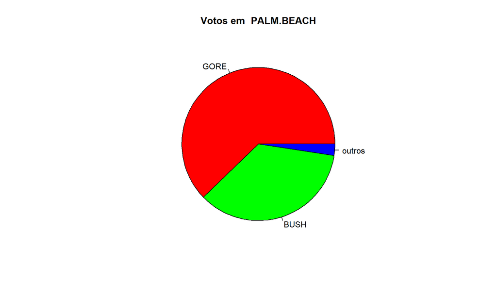

```r
# Selecionar os valores das colunas, exceto a coluna município e total

tf <- as.integer(florida[n, 2:(ncol(florida) - 1)])

# Os dois primerios canditados são muito mais expressivos que os outros Por
# issso irei somar o valor dos restantes

soma <- sum(tf[3:length(tf)])

# Preciso conseguir o nome dos canditados para formar as labels
nomes <- colnames(florida)[2:(ncol(florida) - 1)]

# Faço o grafico de pizza
pie(x = c(tf[1:2], soma), labels = c(nomes[1:2], "outros"), col = rainbow(3), main = paste("Votos em ",
  florida[n, 1]))
```

# Qualquer ordem

O primeiro gráfico está enviesado para colocar sempre o nome de Bush ou Gore. Nestes casos não é o problema, pois ambos disputaram o primeiro e segundo lugar em todos os municípios.

Mas será que conseguiríamos fazer, a porcentagem de votos funcionasse para qualquer caso?

```r
# Qual linha vc quer saber n=11 Selecionar linha desejada e os valores das
# colunas, exceto a coluna total

tf <- as.integer(florida[n, 2:(ncol(florida) - 1)])
tf
```

```
##  [1] 268945 152846   3407   5564    743    143     45    302    103    188
```

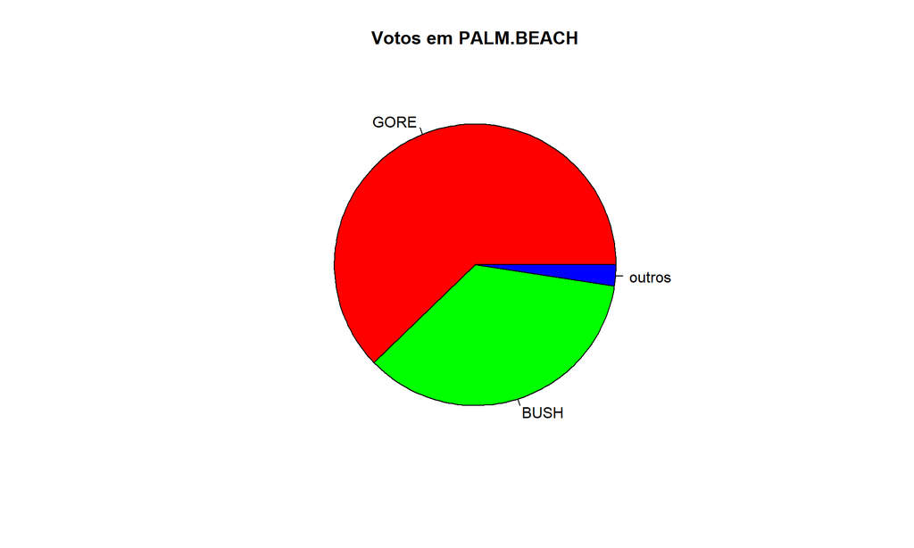

```r
# Os dois primerios canditados são muito mais expressivos que os outros Por
# issso irei somar o valor dos restantes, os colocando em ordem E tire os dois
# maiores valores pra somar o restante

soma <- sum(sort(tf[3:length(tf)]))

# Neste caso, nao faz diferença, mas qual usar? sort(tf[3:length(tf)])
# tf[3:length(sort(tf))]



# Preciso conseguir o nome dos canditados para formar as labels Irei reordenar
# os nomes, dependendo doa valores de tf como referencia Como eles viram
# fatores Eu os pego noa sua ordem de significância
nomes <- levels(reorder(colnames(florida)[2:(ncol(florida) - 1)], -tf))

# Para facilitar na construção de gráfico, eu irei ordenar os dois primeiros
# valores de tf em uma variavel
ordem <- sort(tf[1:2], decreasing = T)
# Faço o grafico de pizza
pie(x = c(ordem, soma), labels = c(nomes[1:2], "outros"), col = rainbow(3), main = paste("Votos em",
  florida[n, 1]))
```

# O que aprendemos?

A disputa foi realmente acirrada em relação aos dois candidatos, Gore e Bush. E segundo informações da época, a Flórida foi o Estado decisivo para o rumo da eleição.

Uma coisa que também aprendi com esse pequeno projeto é… E consigo fazer uma análise simplificada :D

Bem pessoal, até a próxima.